# 320 Final Project

Amy Vuong, Katheryn Fox, Shawdi Hootkany

5/22/2019

# Introduction

In the US, attending college is a true financial investment. Students take out hundreds of thousands of dollars in student loans, to attend school and earn their degree. According to [studentloanhero.com](https://studentloanhero.com/student-loan-debt-statistics/), 69% of the graduating class of 2018 left school with student loans, with an average debt of $29,800. Altogether, American citizens “owe over $1.56 trillion in student loan debt, spread out among about 45 million borrowers” ([studentloanhero.com](https://studentloanhero.com/student-loan-debt-statistics/)).

This crisis centers around money: paying for college as well as the ability to pay off student debt after graduation.

To better understand the statistics and relationships between factors of these costs and salaries, we found a dataset that could provide financial information about students and costs as well as extensive information about the schools themselves. This provides greater insight into the possible driving factors behind published statistics like median starting salary and school tuition prices.

### The Dataset

Utilizing the publicly available and widely trusted source, [U.S. News 2019 Best National Univeristy](https://www.usnews.com/best-colleges/rankings/national-universities) ranking list, we were able to access information about top schools that was organized in a digestable and scrapable manner.

We obtained information regarding 12 different variables (using the URL and School Name to uniquely identify the Univerisities):

- Tuition Cost (in USD - out of state tuition used if university is a state school)
- Room & Board (in USD)
- Total Enrollment
- School Type (Private/Public)
- Year Founded
- Setting
- Endowment 2017
- Median Starting Salary Of Alumni (3 years postgraduate)
- Selectivity
- Fall 2017 Acceptance Rate
- Male Percentage
- Four Year Graduation Rate

We chose to use the top 110, removing one row, because of data inconsistency, as it did not provide a Median Starting Salary for Alumni. This was the University of California–Davis.

### Research Questions

- What variables are statistically significant in predicting college tuition prices?
  - Which factors seem to drive the biggest increases?
  - Does a higher endowment mean that students have to spend less on tuition? (i.e. does it appear that schools use their endowments to supplement tuition prices at all?)
- What variables are statistically significant in predicting median starting salary for alumni (with 3 years of experience post-grad)?
  - Is the cost of undergraduate tuition a key factor? (i.e. spending more on education correlated with getting more money later?)
  - Is median starting salary correlated with the male to female ratio at the institution in any kind of way?

### Required Tools

You will use R and the following libraries:

- ggplot2
- rvest
- tidyverse
- stringr

# Part 1: Data Acquisition

### Part 1A: Scraping

The main url we will be using contains very limited information about each of the schools, such as ranking and tuition, therefore the first step that needs to be taken to be able to gain all the information we need to be able to analyze the data and make predictions is to parse the information into readable data. Detailed information about each school is spread across multiple websites so we will need to retrieve the proper url for each university from the US News website containing the ranking and then parse important information into tables that could be used for data analysis.

We are scraping the data of 110 schools from https://www.usnews.com/best-colleges/rankings/national-universities. The data we have is stored in a text file since it loads on the page in increments. We parse the data to find the URL for each college’s informational page.

```r
library(rvest)
library(tidyverse)
url <-"html_top100.txt"
college_urls <- url %>%
  read_html() %>%
  html_node("body") %>% html_nodes("ol[class~=bEyEue]") %>% html_nodes("li[id]")%>% html_nodes("h3") %>%
  html_nodes("a[href]") %>%
  html_attr("href")
head(college_urls)
```

```
## [1] "/best-colleges/princeton-university-2627"
## [2] "/best-colleges/harvard-university-2155"
## [3] "/best-colleges/columbia-university-2707"
## [4] "/best-colleges/massachusetts-institute-of-technology-2178"
## [5] "/best-colleges/university-of-chicago-1774"
## [6] "/best-colleges/yale-university-1426"
```

A data frame is created to store the information of each college in rows. Columns are initialized with their corresponding default values.

```r
index_num <- 0

college_tab_1 <-  data.frame("URL" = gsub(" ", "", paste("https://www.usnews.com",college_urls, sep = "")),
"CollegeName"= "", "TuitionFeesThousands" = 0, "RoomBoardThousands" = 0, "TotalEnrollment" = 0, "SchoolType" = "", "YearFounded" = 0, "Setting" = "", "Endowment2017Millions" = 0, "MedianStartingSalaryOfAlumniThousands" = 0, "Selectivity" = "", "Fall2017AcceptanceRate" = 0, "MalePercentage" = 0, "FourYearGraduationRate" = 0, stringsAsFactors = FALSE)

#removing one college that doesn't have a median starting salary, for data uniformity
college_tab_1 <- college_tab_1[-c(40),]
```

Below are functions used to obtain data from the website and parse it.

```r
#retrieves of vector of size three containing the Tuition&Fees, Room&Board, and total enrollment
get_info <- function(url_html){
  attr <- url_html %>% html_node("body") %>% html_nodes("div[id~=content-main]") %>%
    html_nodes("section[class~=hero-stats-widget-stats]") %>%
    html_nodes("ul") %>% html_nodes("li") %>% html_nodes("strong")
}

#takes in a vector and index, and parses that information to a double
#ex: $47,263 -> 47263.0
get_tuition_rm <- function(info, num){
  a_1 <- info[num] %>%  html_text()
  tuition_rm <-
    as.double(paste(substring(a_1, 2, str_locate(a_1, ",")[1] - 1), substring(a_1, str_locate(a_1, ",")[1] + 1, str_locate(a_1, " ")[1] - 1), sep=""))
  tuition_rm / 1000.0
}

#takes in a vector and parses the total enrollment information to a double
get_enrollment <- function(info){
  a_1 <- info[3] %>%  html_text()
  as.double(paste(substring(a_1, 1, str_locate(a_1, ",")[1] - 1), substring(a_1, str_locate(a_1, ",")[1] + 1), sep=""))
}

#gets the percentage of the majority gender at a certain university
get_percent <- function(url_html){
  attr <- url_html %>% html_node("body") %>% html_nodes("div[id~=content-main]") %>%
    html_nodes("div[class~=block-normal]") %>% html_nodes("span[class~=distribution-breakdown__percentage]") %>% html_text()
  as.double(substring(attr, 1, str_locate(attr, "%")[1] - 1)) / 100.0
}

#retrieves the gender of the majority sex and parses the percentage to be in terms of males
get_gender_ratio <- function(url_html){
  attr <- url_html %>% html_node("body") %>% html_nodes("div[id~=content-main]") %>%
    html_nodes("div[class~=block-normal]") %>% html_nodes("span[class~=distribution-breakdown__percentage-copy]") %>% html_text()
  attr <- sub("\n                    ","",attr)
  attr <- sub("\n                ","",attr)
  if (attr == "Female"){
    1 - get_percent(url_html)
  }else{
    get_percent(url_html)
  }
}
```

Here, we use both the functions above and the html_node function to fill out the table.

```r
college_tab <- college_tab_1

for (i in 1:nrow(college_tab)){
  url_html <- college_tab[i,1] %>%read_html()
  college_tab[i,]$CollegeName <- url_html %>% html_node("body") %>% html_nodes("h1[class~=hero-heading]") %>% html_text()
  priv_tuition <- url_html %>% html_node("body") %>% html_nodes("span[data-test-id~=v_private_tuition]") %>% html_text()
  college_tab[i,]$TuitionFeesThousands <- ifelse(length(priv_tuition) > 0, priv_tuition,
                                                 url_html %>% html_node("body") %>% html_node("span[data-test-id~=v_out_state_tuition]") %>% html_text())
  college_tab[i,]$RoomBoardThousands <- url_html %>% html_node("body") %>% html_node("span[data-test-id~=w_room_board]") %>% html_text()
  college_tab[i,]$TotalEnrollment <- url_html %>% html_node("body") %>% html_node("span[data-test-id~=total_all_students]") %>% html_text()
  college_tab[i,]$MalePercentage <- get_gender_ratio(url_html)
  college_tab[i,]$Fall2017AcceptanceRate <- url_html %>% html_node("span[data-test-id~=r_c_accept_rate]") %>% html_text()
  college_tab[i,]$Selectivity <- url_html %>% html_node("span[data-test-id~=c_select_class]") %>% html_text()
  college_tab[i,]$FourYearGraduationRate <- url_html %>% html_node("span[data-test-id~=grad_rate_4_year]") %>% html_text()
  college_tab[i,]$MedianStartingSalaryOfAlumniThousands <-  url_html %>% html_nodes("div[data-field-id=averageStartSalary]") %>%html_node("span[data-test-id]") %>% html_text()
  temp_vector <- url_html %>% html_node("body") %>% html_nodes("div[id~=content-main]") %>%html_nodes("div[class~=flex-row]") %>%   html_nodes("span[class~=heading-small]") %>% html_text()
  college_tab[i,]$SchoolType <- temp_vector[1]
  college_tab[i,]$YearFounded <- temp_vector[2]
  college_tab[i,]$Setting <- temp_vector[5]
  college_tab[i,]$Endowment2017Millions  <- temp_vector[6]
}

head(college_tab)
```

```
##                                                                               URL
## 1                  https://www.usnews.com/best-colleges/princeton-university-2627
## 2                    https://www.usnews.com/best-colleges/harvard-university-2155
## 3                   https://www.usnews.com/best-colleges/columbia-university-2707
## 4 https://www.usnews.com/best-colleges/massachusetts-institute-of-technology-2178
## 5                 https://www.usnews.com/best-colleges/university-of-chicago-1774
## 6                       https://www.usnews.com/best-colleges/yale-university-1426
##                                             CollegeName
## 1                  \n        Princeton University\n
## 2                    \n        Harvard University\n
## 3                   \n        Columbia University\n
## 4 \n        Massachusetts Institute of Technology\n
## 5                 \n        University of Chicago\n
## 6                       \n        Yale University\n
##              TuitionFeesThousands              RoomBoardThousands
```

[output cut: 34 more lines]

### Part 1B: Data Cleaning & Tidying

Below, we reformat many of the columns to get usable data. Each column is categorized into the appropriate type of data.

Note: We transform Room and Board, Tuition and Fees, and Median Alumni Salary so they are all in thousands of dollars. We transform Endowment so that it is in millions of dollars.

```r
formatted_college_tab <- college_tab
#fix type of School Type, Setting, Year Founded
formatted_college_tab$SchoolType <- as.factor(formatted_college_tab$SchoolType)
formatted_college_tab$Setting <- as.factor(formatted_college_tab$Setting)
formatted_college_tab$YearFounded <- as.integer(formatted_college_tab$YearFounded)
#fix Endowment2017 formatting
formatted_college_tab$Endowment2017Millions  <- ifelse(grepl("billion", formatted_college_tab$Endowment2017Millions ), sub("\\.","",formatted_college_tab$Endowment2017Millions ),formatted_college_tab$Endowment2017Millions )
formatted_college_tab$Endowment2017Millions  <-sub(" billion","00",formatted_college_tab$Endowment2017Millions )
formatted_college_tab$Endowment2017Millions  <-sub(" million","",formatted_college_tab$Endowment2017Millions )
formatted_college_tab$Endowment2017Millions  <-sub("[[:punct:]]", "",formatted_college_tab$Endowment2017Millions )
formatted_college_tab$Endowment2017Millions  <-sub("\\$", "",formatted_college_tab$Endowment2017Millions )
formatted_college_tab$Endowment2017Millions  <-sub(" \\+", "",formatted_college_tab$Endowment2017Millions )
formatted_college_tab$Endowment2017Millions <- as.double(formatted_college_tab$Endowment2017Millions)
#fix College Name formatting
formatted_college_tab$CollegeName <- sub("^\n        ","",formatted_college_tab$CollegeName)
formatted_college_tab$CollegeName <-sub("\n    ","",formatted_college_tab$CollegeName)
#fixing Acceptance Rate formatting
formatted_college_tab$Fall2017AcceptanceRate <- sub("\n            ","",formatted_college_tab$Fall2017AcceptanceRate)
formatted_college_tab$Fall2017AcceptanceRate <- sub("%","",formatted_college_tab$Fall2017AcceptanceRate)
formatted_college_tab$Fall2017AcceptanceRate <- as.double(formatted_college_tab$Fall2017AcceptanceRate)
formatted_college_tab$Fall2017AcceptanceRate <- formatted_college_tab$Fall2017AcceptanceRate/100
#fixing Grad Rate formatting
formatted_college_tab$FourYearGraduationRate <- sub("\n            ","",formatted_college_tab$FourYearGraduationRate)
formatted_college_tab$FourYearGraduationRate <- sub("%","",formatted_college_tab$FourYearGraduationRate)
formatted_college_tab$FourYearGraduationRate <- as.double(formatted_college_tab$FourYearGraduationRate)
formatted_college_tab$FourYearGraduationRate <- formatted_college_tab$FourYearGraduationRate/100
#fixing Salary formatting
formatted_college_tab$MedianStartingSalaryOfAlumniThousands <-
  sub("\n            ","",formatted_college_tab$MedianStartingSalaryOfAlumniThousands)
formatted_college_tab$MedianStartingSalaryOfAlumniThousands <- gsub("\\*","",formatted_college_tab$MedianStartingSalaryOfAlumniThousands)
formatted_college_tab$MedianStartingSalaryOfAlumniThousands <- gsub("\\$","",formatted_college_tab$MedianStartingSalaryOfAlumniThousands)
formatted_college_tab$MedianStartingSalaryOfAlumniThousands <- gsub("\\,","",formatted_college_tab$MedianStartingSalaryOfAlumniThousands)
formatted_college_tab$MedianStartingSalaryOfAlumniThousands <- as.double(formatted_college_tab$MedianStartingSalaryOfAlumniThousands)/1000
#fixing Selectivity formatting
formatted_college_tab$Selectivity <- sub("\n            ","",formatted_college_tab$Selectivity)
formatted_college_tab$Selectivity <- as.factor(formatted_college_tab$Selectivity)
#fixing Tuition formatting
formatted_college_tab$TuitionFeesThousands <- sub("\n            ", "",formatted_college_tab$TuitionFeesThousands )
formatted_college_tab$TuitionFeesThousands <- sub(" \\(2018-19\\)", "",formatted_college_tab$TuitionFeesThousands )
formatted_college_tab$TuitionFeesThousands  <-sub("\\,", "",formatted_college_tab$TuitionFeesThousands )
formatted_college_tab$TuitionFeesThousands  <-sub("\\$", "",formatted_college_tab$TuitionFeesThousands )
formatted_college_tab$TuitionFeesThousands <- as.double(formatted_college_tab$TuitionFeesThousands)/1000
#fixing RoomBoard formatting
formatted_college_tab$RoomBoardThousands <- sub("\n            ", "",formatted_college_tab$RoomBoardThousands )
formatted_college_tab$RoomBoardThousands <- sub(" \\(2018-19\\)", "",formatted_college_tab$RoomBoardThousands )
formatted_college_tab$RoomBoardThousands  <-sub("\\,", "",formatted_college_tab$RoomBoardThousands )
formatted_college_tab$RoomBoardThousands  <-sub("\\$", "",formatted_college_tab$RoomBoardThousands )
formatted_college_tab$RoomBoardThousands <- as.double(formatted_college_tab$RoomBoardThousands)/1000
#fixing Enrollment formatting
formatted_college_tab$TotalEnrollment <- sub("\n            ", "",formatted_college_tab$TotalEnrollment )
formatted_college_tab$TotalEnrollment  <-sub("\\,", "",formatted_college_tab$TotalEnrollment )
formatted_college_tab$TotalEnrollment <- as.double(formatted_college_tab$TotalEnrollment)

#adding another column with total cost
formatted_college_tab <- formatted_college_tab %>% mutate(TotalCostThousands =TuitionFeesThousands + RoomBoardThousands )

formatted_college_tab <- na.omit(formatted_college_tab)
as.tibble(formatted_college_tab)
```

```
## # A tibble: 107 x 15
##    URL   CollegeName TuitionFeesThou… RoomBoardThousa… TotalEnrollment
##    <chr> <chr>                  <dbl>            <dbl>           <dbl>
##  1 http… Princeton …             47.1             15.6            8273
##  2 http… Harvard Un…             50.4             17.2           20604
##  3 http… Columbia U…             59.4             14.0           25968
##  4 http… Massachuse…             51.8             15.5           11466
##  5 http… University…             57.0             16.4           13736
##  6 http… Yale Unive…             53.4             16             12974
##  7 http… Stanford U…             51.4             15.8           17178
##  8 http… Duke Unive…             56.0             15.9           16294
##  9 http… University…             55.6             15.6           21907
## 10 http… Johns Hopk…             53.7             15.8           25151
## # … with 97 more rows, and 10 more variables: SchoolType <fct>,
## #   YearFounded <int>, Setting <fct>, Endowment2017Millions <dbl>,
## #   MedianStartingSalaryOfAlumniThousands <dbl>, Selectivity <fct>,
## #   Fall2017AcceptanceRate <dbl>, MalePercentage <dbl>,
## #   FourYearGraduationRate <dbl>, TotalCostThousands <dbl>
```

# Part 2: Data Visualization

We plot the data in order to visualize relationships among the attributes.

### Part 2A: Starting Salary Distribution

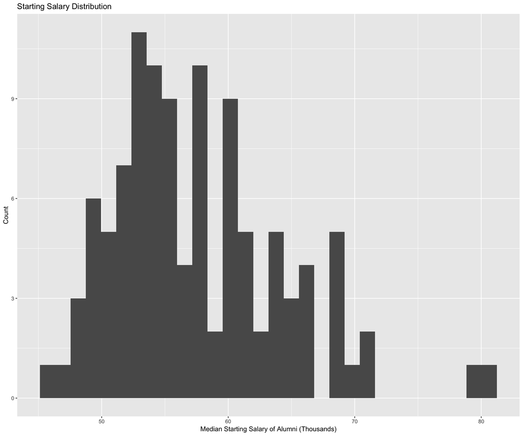

```r
#Starting Salary
#-histograms
library(ggplot2)
plot_1 <- formatted_college_tab %>%
  ggplot(aes(MedianStartingSalaryOfAlumniThousands)) +
    geom_histogram()+
    labs(title="Starting Salary Distribution", x="Median Starting Salary of Alumni (Thousands)", y="Count")
plot_1
```

The distribution of the median starting salary of alumni from all the school seems to be a bell-shaped curve (a little skewed right), centering around $55,000.

### Part 2B: Tuition Cost Distrubition

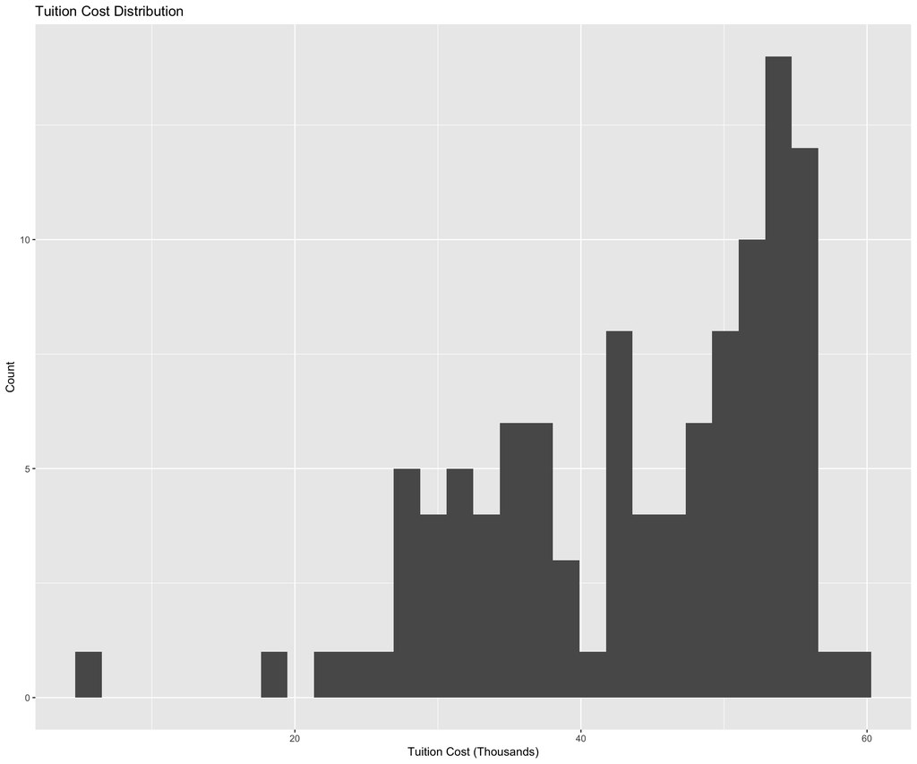

```r
#Tuition Cost
#-histograms
library(ggplot2)
plot_2 <- formatted_college_tab %>%
  ggplot(aes(TuitionFeesThousands)) +
    geom_histogram()+
        labs(title="Tuition Cost Distribution", x="Tuition Cost (Thousands)", y="Count")
plot_2
```

The distribution of tution costs of all the schools is skewed left, with a range of $60,000.

# Part 3: Model Fitting and Selection

### Part 3A: Data Preparation

Begin by removing the two columns with identifying information, as these are not useful in fitting models.

```r
#adjusting dataset to remove variables not able to be used in model fitting
college_info <- formatted_college_tab[,-c(1,2)]
head(college_info)
```

```
##   TuitionFeesThousands RoomBoardThousands TotalEnrollment    SchoolType
## 1               47.140             15.610            8273 Private, Coed
## 2               50.420             17.160           20604 Private, Coed
## 3               59.430             14.016           25968 Private, Coed
## 4               51.832             15.510           11466 Private, Coed
## 5               57.006             16.350           13736 Private, Coed
## 6               53.430             16.000           12974 Private, Coed
##   YearFounded  Setting Endowment2017Millions
## 1        1746 Suburban                 23400
## 2        1636    Urban                 37100
## 3        1754    Urban                 10000
## 4        1861    Urban                 14800
## 5        1890    Urban                  6600
## 6        1701     City                 27200
##   MedianStartingSalaryOfAlumniThousands    Selectivity
```

[output cut: 20 more lines]

To get a clearer picture of how a percentage increase affects the tuition cost, it’s important to put these values back into whole numbers rather than proportions - this will make interpretation clearer.

```r
college_info$FourYearGraduationRate <- college_info$FourYearGraduationRate*100
college_info$MalePercentage <- college_info$MalePercentage*100
college_info$Fall2017AcceptanceRate <- college_info$Fall2017AcceptanceRate*100
```

## Hypothesis Testing

Hypothesis testing allows us to make a claim against what is believed to be true and through different forms of testing, determine whether there is sufficient evidence towards believing that claim is true. In the following sections, conclusions will be made based on results of hypothesis tests. The p-value for a model determines the significance of the model compared with a null model. A p-value smaller than our significance level indicates strong evidence against the null hypothesis, allowing us to reject the null for the alternative hypothesis.

In an example for testing whether there is a relationship between Tuition and School Type, our null hypothesis states that there is no correlation between Tuition and School Type and our alternative hypothesis states that there is a relationship between those two variables. There are many ways to test a hypothesis but we will be looking at r-squared values. The r-squared value measures the degree to which the data is explained by the model.

The r-squared value in the following model is about 0.54, meaning our model explains about 54% of the variation within the data. No direct conclusion can be made using the r-squared value but alongside the p-value, which is very small, it could be said that our model explains a large amount of the variation within our data, more than 50%, and is significant. We can therefore reject the null hypothesis because our model gives us results that is not consistent with the null hypothesis. There is significant evidence towards accepting the fact that there is a correlation between Tuition and School Type.

```r
model = lm(TuitionFeesThousands ~ SchoolType,
           data = college_info)

summary(model)
```

```
##
## Call:
## lm(formula = TuitionFeesThousands ~ SchoolType, data = college_info)
##
## Residuals:
##     Min      1Q  Median      3Q     Max
## -44.871  -3.046   1.337   3.859  14.481
##
## Coefficients:
##                        Estimate Std. Error t value Pr(>|t|)
## (Intercept)             50.4906     0.9234   54.68   <2e-16 ***
## SchoolTypePublic, Coed -15.6220     1.4083  -11.09   <2e-16 ***
## ---
## Signif. codes:  0 '***' 0.001 '**' 0.01 '*' 0.05 '.' 0.1 ' ' 1
##
## Residual standard error: 7.212 on 105 degrees of freedom
## Multiple R-squared:  0.5396, Adjusted R-squared:  0.5352
## F-statistic:   123 on 1 and 105 DF,  p-value: < 2.2e-16
```

## Part 3B:Fitting model for tuition prices

First, fit the model using the [lm function](https://www.rdocumentation.org/packages/stats/versions/3.6.0/topics/lm). From R documentation: “A typical model has the form response ~ terms where response is the (numeric) response vector and terms is a series of terms which specifies a linear predictor for response.” Here, we set the response variable to be tuition costs and the terms to be all variables except room and board costs and total costs, as they are extremely highly correlated (as tuition is also a part of total cost).

```r
tuition_lm_1 <- lm(TuitionFeesThousands~.-RoomBoardThousands-TotalCostThousands, data = college_info)
summary(tuition_lm_1)
```

```
##
## Call:
## lm(formula = TuitionFeesThousands ~ . - RoomBoardThousands -
##     TotalCostThousands, data = college_info)
##
## Residuals:
##     Min      1Q  Median      3Q     Max
## -32.860  -2.743   0.146   3.237  14.500
##
## Coefficients:
##                                         Estimate Std. Error t value
## (Intercept)                            1.491e+01  2.646e+01   0.563
## TotalEnrollment                       -3.283e-05  5.921e-05  -0.555
## SchoolTypePublic, Coed                -1.150e+01  1.909e+00  -6.021
## YearFounded                            4.876e-03  1.305e-02   0.374
## SettingRural                           2.112e-01  2.878e+00   0.073
## SettingSuburban                        1.191e+00  1.695e+00   0.703
## SettingUrban                           1.695e+00  1.611e+00   1.052
## Endowment2017Millions                 -5.211e-05  1.483e-04  -0.351
## MedianStartingSalaryOfAlumniThousands  1.396e-01  1.705e-01   0.819
## SelectivityMost selective              4.546e+00  2.168e+00   2.096
## SelectivitySelective                  -6.810e+00  4.740e+00  -1.437
## Fall2017AcceptanceRate                 5.185e-02  5.897e-02   0.879
## MalePercentage                         2.208e-02  1.319e-01   0.167
## FourYearGraduationRate                 1.754e-01  4.529e-02   3.873
##                                       Pr(>|t|)
## (Intercept)                             0.5745
## TotalEnrollment                         0.5806
## SchoolTypePublic, Coed                3.42e-08 ***
## YearFounded                             0.7095
## SettingRural                            0.9417
## SettingSuburban                         0.4841
## SettingUrban                            0.2957
## Endowment2017Millions                   0.7262
## MedianStartingSalaryOfAlumniThousands   0.4151
## SelectivityMost selective               0.0388 *
## SelectivitySelective                    0.1541
## Fall2017AcceptanceRate                  0.3815
## MalePercentage                          0.8674
## FourYearGraduationRate                  0.0002 ***
## ---
## Signif. codes:  0 '***' 0.001 '**' 0.01 '*' 0.05 '.' 0.1 ' ' 1
##
## Residual standard error: 6.182 on 93 degrees of freedom
## Multiple R-squared:  0.7003, Adjusted R-squared:  0.6584
## F-statistic: 16.72 on 13 and 93 DF,  p-value: < 2.2e-16
```

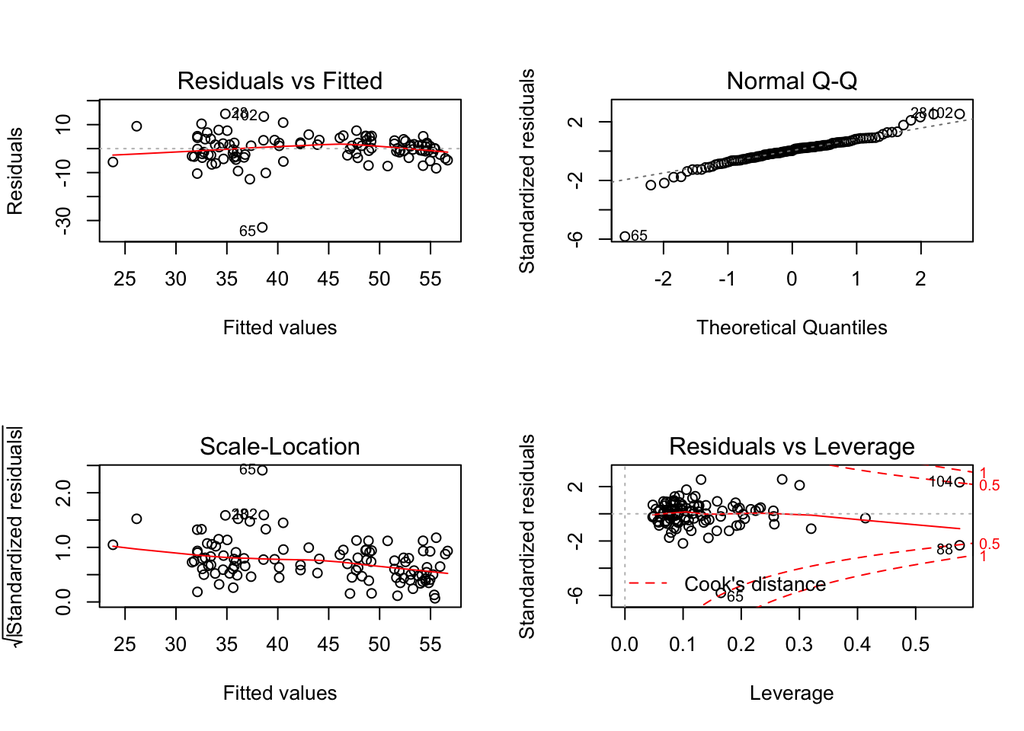

```r
par(mfrow=c(2,2))
plot(tuition_lm_1)
```

Looking at both the summary statistics, and summary plots, stepwise selection (using the [step function](https://www.rdocumentation.org/packages/stats/versions/3.6.0/topics/step)) will be useful in obtaining a better model.

```r
tuition_lm_2 <- step(tuition_lm_1, direction = "both", steps = 1000, trace = F)
summary(tuition_lm_2)
```

```
##
## Call:
## lm(formula = TuitionFeesThousands ~ SchoolType + Selectivity +
##     FourYearGraduationRate, data = college_info)
##
## Residuals:
##     Min      1Q  Median      3Q     Max
## -35.663  -2.870   0.402   3.025  14.015
##
## Coefficients:
##                            Estimate Std. Error t value Pr(>|t|)
## (Intercept)                37.98706    2.52629  15.037  < 2e-16 ***
## SchoolTypePublic, Coed    -12.40552    1.29191  -9.602 6.18e-16 ***
## SelectivityMost selective   4.03690    1.42380   2.835 0.005521 **
## SelectivitySelective       -7.47358    4.37232  -1.709 0.090437 .
## FourYearGraduationRate      0.14329    0.03637   3.940 0.000149 ***
## ---
## Signif. codes:  0 '***' 0.001 '**' 0.01 '*' 0.05 '.' 0.1 ' ' 1
##
## Residual standard error: 6.049 on 102 degrees of freedom
## Multiple R-squared:  0.6854, Adjusted R-squared:  0.6731
## F-statistic: 55.55 on 4 and 102 DF,  p-value: < 2.2e-16
```

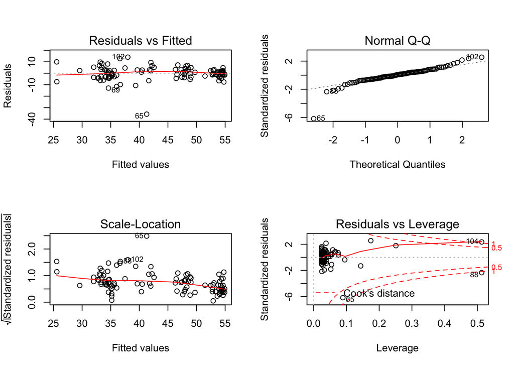

```r
par(mfrow=c(2,2))
plot(tuition_lm_2)
```

Looking at the summary statistics, we can see that the model is now reduced and only has SchoolType, Selectivity, and 4-year graduation rate as remaining predictors that are considered to be significantly significant in predicting the response variable.

```r
anova(tuition_lm_1,tuition_lm_2)
```

```
## Analysis of Variance Table
##
## Model 1: TuitionFeesThousands ~ (RoomBoardThousands + TotalEnrollment +
##     SchoolType + YearFounded + Setting + Endowment2017Millions +
##     MedianStartingSalaryOfAlumniThousands + Selectivity + Fall2017AcceptanceRate +
##     MalePercentage + FourYearGraduationRate + TotalCostThousands) -
##     RoomBoardThousands - TotalCostThousands
## Model 2: TuitionFeesThousands ~ SchoolType + Selectivity + FourYearGraduationRate
##   Res.Df    RSS Df Sum of Sq      F Pr(>F)
## 1     93 3554.7
## 2    102 3731.7 -9   -176.99 0.5145 0.8607
```

## Part 3C: Fitting model for Median Starting Salary

Using much of the same procedure, we decided to investigate Median Starting Salaries.

```r
startingsalary_lm_1 <- lm(MedianStartingSalaryOfAlumniThousands~.-TuitionFeesThousands-RoomBoardThousands, data = na.omit(college_info))
summary(startingsalary_lm_1)
```

```
##
## Call:
## lm(formula = MedianStartingSalaryOfAlumniThousands ~ . - TuitionFeesThousands -
##     RoomBoardThousands, data = na.omit(college_info))
##
## Residuals:
##     Min      1Q  Median      3Q     Max
## -7.3062 -2.3889 -0.2445  1.8739 15.6698
##
## Coefficients:
##                             Estimate Std. Error t value Pr(>|t|)
## (Intercept)                1.976e+01  1.595e+01   1.239   0.2186
## TotalEnrollment            8.453e-06  3.614e-05   0.234   0.8156
## SchoolTypePublic, Coed    -1.430e+00  1.325e+00  -1.079   0.2833
## YearFounded                5.017e-03  7.928e-03   0.633   0.5284
## SettingRural               1.384e+00  1.741e+00   0.795   0.4286
## SettingSuburban           -2.983e-01  1.032e+00  -0.289   0.7732
## SettingUrban               3.407e-01  9.871e-01   0.345   0.7308
## Endowment2017Millions      2.166e-04  8.718e-05   2.485   0.0147 *
## SelectivityMost selective  2.481e+00  1.326e+00   1.872   0.0644 .
## SelectivitySelective       2.567e+00  2.885e+00   0.890   0.3759
## Fall2017AcceptanceRate    -8.235e-02  3.478e-02  -2.368   0.0200 *
## MalePercentage             5.486e-01  5.637e-02   9.732 7.55e-16 ***
## FourYearGraduationRate     1.843e-02  2.907e-02   0.634   0.5276
## TotalCostThousands         3.458e-02  5.496e-02   0.629   0.5307
## ---
## Signif. codes:  0 '***' 0.001 '**' 0.01 '*' 0.05 '.' 0.1 ' ' 1
##
## Residual standard error: 3.752 on 93 degrees of freedom
## Multiple R-squared:  0.7248, Adjusted R-squared:  0.6864
## F-statistic: 18.85 on 13 and 93 DF,  p-value: < 2.2e-16
```

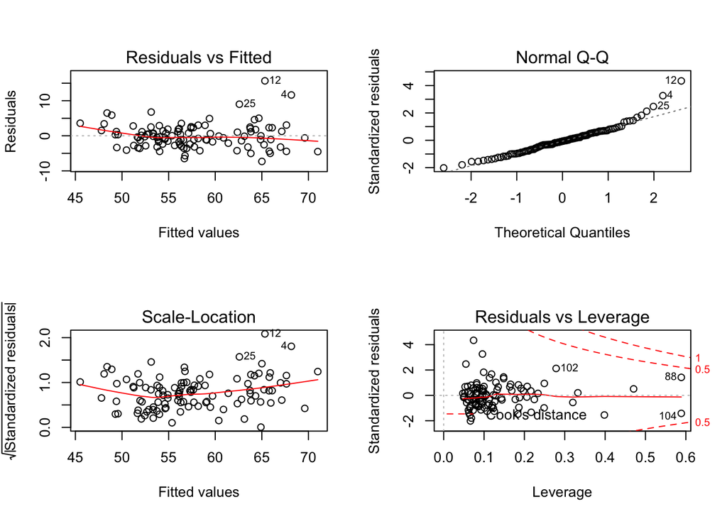

```r
par(mfrow=c(2,2))
plot(startingsalary_lm_1)
```

```r
startingsalary_lm_2 <- step(startingsalary_lm_1, direction = "both", steps = 1000, trace = F)
summary(startingsalary_lm_2)
```

```
##
## Call:
## lm(formula = MedianStartingSalaryOfAlumniThousands ~ SchoolType +
##     Endowment2017Millions + Selectivity + Fall2017AcceptanceRate +
##     MalePercentage, data = na.omit(college_info))
##
## Residuals:
##     Min      1Q  Median      3Q     Max
## -6.5908 -2.3830 -0.3075  1.8991 15.2461
##
## Coefficients:
##                             Estimate Std. Error t value Pr(>|t|)
## (Intercept)                3.341e+01  2.874e+00  11.625  < 2e-16 ***
## SchoolTypePublic, Coed    -1.912e+00  8.010e-01  -2.386  0.01889 *
## Endowment2017Millions      1.998e-04  7.306e-05   2.735  0.00738 **
## SelectivityMost selective  2.697e+00  1.244e+00   2.168  0.03252 *
## SelectivitySelective       2.042e+00  2.713e+00   0.752  0.45357
## Fall2017AcceptanceRate    -9.100e-02  3.173e-02  -2.868  0.00504 **
## MalePercentage             5.428e-01  4.828e-02  11.243  < 2e-16 ***
## ---
## Signif. codes:  0 '***' 0.001 '**' 0.01 '*' 0.05 '.' 0.1 ' ' 1
##
## Residual standard error: 3.672 on 100 degrees of freedom
## Multiple R-squared:  0.7166, Adjusted R-squared:  0.6996
## F-statistic: 42.15 on 6 and 100 DF,  p-value: < 2.2e-16
```

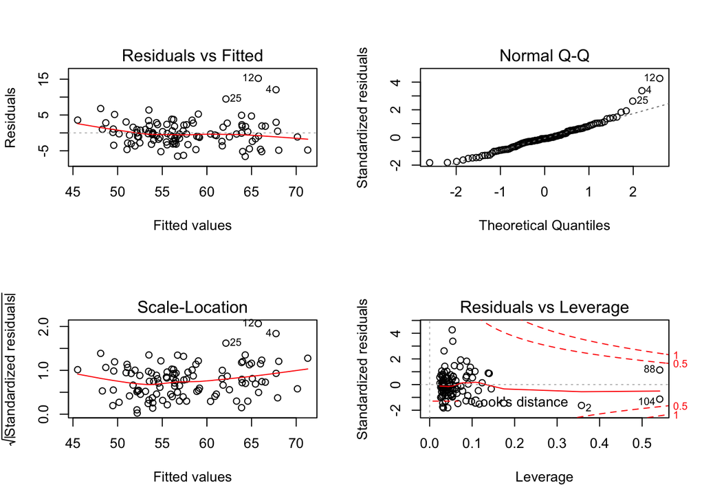

```r
par(mfrow=c(2,2))
plot(startingsalary_lm_2)
```

```r
anova(startingsalary_lm_1,startingsalary_lm_2)
```

```
## Analysis of Variance Table
##
## Model 1: MedianStartingSalaryOfAlumniThousands ~ (TuitionFeesThousands +
##     RoomBoardThousands + TotalEnrollment + SchoolType + YearFounded +
##     Setting + Endowment2017Millions + Selectivity + Fall2017AcceptanceRate +
##     MalePercentage + FourYearGraduationRate + TotalCostThousands) -
##     TuitionFeesThousands - RoomBoardThousands
## Model 2: MedianStartingSalaryOfAlumniThousands ~ SchoolType + Endowment2017Millions +
##     Selectivity + Fall2017AcceptanceRate + MalePercentage
##   Res.Df    RSS Df Sum of Sq      F Pr(>F)
## 1     93 1309.3
## 2    100 1348.5 -7    -39.15 0.3973 0.9018
```

```r
startingsalary_lm_3 <- lm(log(MedianStartingSalaryOfAlumniThousands)~.-TuitionFeesThousands-RoomBoardThousands, data = na.omit(college_info))
summary(startingsalary_lm_3)
```

```
##
## Call:
## lm(formula = log(MedianStartingSalaryOfAlumniThousands) ~ . -
##     TuitionFeesThousands - RoomBoardThousands, data = na.omit(college_info))
##
## Residuals:
##       Min        1Q    Median        3Q       Max
## -0.116162 -0.036769 -0.002299  0.032707  0.219392
##
## Coefficients:
##                             Estimate Std. Error t value Pr(>|t|)
## (Intercept)                3.431e+00  2.576e-01  13.315   <2e-16 ***
## TotalEnrollment            3.718e-07  5.836e-07   0.637   0.5257
## SchoolTypePublic, Coed    -2.545e-02  2.140e-02  -1.190   0.2373
## YearFounded                6.492e-05  1.280e-04   0.507   0.6133
## SettingRural               2.939e-02  2.811e-02   1.046   0.2984
## SettingSuburban           -3.348e-03  1.666e-02  -0.201   0.8412
## SettingUrban               7.377e-03  1.594e-02   0.463   0.6446
## Endowment2017Millions      3.420e-06  1.408e-06   2.429   0.0171 *
## SelectivityMost selective  4.219e-02  2.141e-02   1.970   0.0518 .
## SelectivitySelective       3.965e-02  4.659e-02   0.851   0.3970
## Fall2017AcceptanceRate    -1.397e-03  5.617e-04  -2.487   0.0147 *
## MalePercentage             9.340e-03  9.103e-04  10.261   <2e-16 ***
## FourYearGraduationRate     2.469e-04  4.694e-04   0.526   0.6001
## TotalCostThousands         7.514e-04  8.875e-04   0.847   0.3993
## ---
## Signif. codes:  0 '***' 0.001 '**' 0.01 '*' 0.05 '.' 0.1 ' ' 1
##
## Residual standard error: 0.06059 on 93 degrees of freedom
## Multiple R-squared:  0.7439, Adjusted R-squared:  0.708
## F-statistic: 20.77 on 13 and 93 DF,  p-value: < 2.2e-16
```

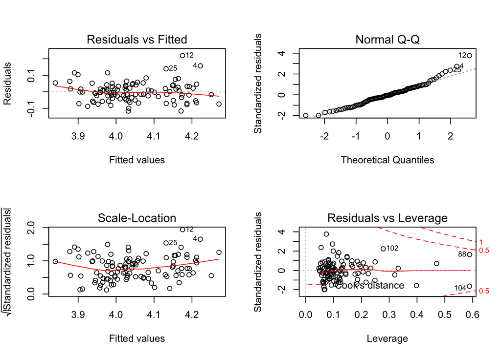

```r
par(mfrow=c(2,2))
plot(startingsalary_lm_3)
```

After transformation, the qq-plot looks a bit more regular, and the summary shows that the Adjusted R-squared value improved from the first model, rising from 0.6864 to 0.708. For more information on why using the Adjusted R-Squared is useful in choosing a model please refer to [this](https://blog.minitab.com/blog/adventures-in-statistics-2/multiple-regession-analysis-use-adjusted-r-squared-and-predicted-r-squared-to-include-the-correct-number-of-variables) resource.

# Conclusion

Being aware of all these factors in succeeding in college is very important when deciding where to go. With all the high stakes involved when choosing to attend college, it’s important to make sure the most worthwhile investment is made. We determined that one of largest factors of the college tuition crisis is the ability of students to pay tuition. For many, the paying of tuition extends until after graduation, and the starting salary of alumni after college plays a large role in assisting alumni for making those payments.

By determining which variables are significant when predicting college tuition and which were important when determining median starting salary for alumni, we were able to come up with an estimate for which colleges will assist students the most for paying the costs of their education. For example, some of the most important factors for determining tuition prices are School Type, Selectivity, and 4-year graduation rate. A student could choose to look at these values when wanting to estimate the tuition they will be paying.

This dataset can be continued to be analyzed to determine many different important factors regarding college education, such as figuring out which factors determine a university’s acceptance rate. Readers could follow the steps provided for performing tests to answer questions of their own.

References: -College Ranking Data: https://www.usnews.com/best-colleges/rankings/national-universities